# alle_meta

Zhijie Zhang

14 March, 2021

This is the code for the paper ‘Effects of allelopathy on plant performance: a meta-analysis’, which which was accepted in *Ecology Letters* in 2020. Please contact Zhijie Zhang (zhijie.zhang@uni-konstanz.de) if any question.

**Variables**:

**eff_size:** lnRR  
**var:** sampling error variance  
**se:** sampling error  
**m_ck, se_ck, sd_ck, n_ck:** mean, se, sd and replication of control treatment  
**m_t, se_t, sd_t, n_t:** mean, se, sd and replication of allelopathy treatment

**Fixed effects:**

1. **study design:**
- **method:** seven methods that were used to test allelopathy (leachate, residue, exudate, volatile, soil, AC [activated carbon], solvent)
- **trait:** germination vs growth
- **door:** controlled, semi-natural vs natural environment
- **duration**
- **dose:** concentration of leachate/residue
- **color:** fresh biomass vs litter
- **plantpart:** above-, below- vs total biomass
2. **biological traits:**
- **lifespan:** short-lived (annual, biennial) vs long-lived (perennial)
- **lifeform:** herb vs tree
- **crop:** crop vs wild
3. **evolutionary history:**
- **pd:** phylogenetic distance
- **origin_3level:** native, non-naturalized alien vs naturalized alien
- **origin:** native vs alien

**xx_allelo** and **xx_test** indicate the infomation of allelopathy and test plants, respecitively.  
**xx_dummy** is dichotomous version of categorical variables with two levels.  
**xx_scale** is the variable after mean/median-centering.

**Random effects:**  
**Ref_ID**: Identity of paper.  
**xx_spp** : Identitiy of species [phylogenetic part].  
**xx_spp_nonphylo** : Identitiy of species [NON-phylogenetic part]

```r
library(knitr)
library(tidyverse)
library(brms)
library(ape)
library(coda)
library(modelr)
library(gridExtra)
library(pBrackets)
library(RColorBrewer)
library(performance)
library(phytools)
library(kableExtra)
library(tidybayes)
library(formattable)
library(grid)
library(Taxonstand)
knitr::opts_chunk$set(message = F,warning = F)
```

```r
load('brms.RData') # I saved the output so that I don't have to re-run the analyses.
```

functions

```r
Ftable <- function(model, reorder = F, order, percent = F){
  table <- summary(model)$fixed
  table2 <-summary(model, prob = 0.9)$fixed %>% as_tibble()
  names <- rownames(table)
  table <- table %>%
    as_tibble() %>%
    rename('L95%CL' = `l-95% CI`, 'U95%CL' = `u-95% CI`) %>%
    select(-Rhat, -Bulk_ESS, -Tail_ESS)
  table$`L90%CL` <- table2$`l-90% CI`
  table$`U90%CL` <- table2$`u-90% CI`

  if (percent == T){
    table <- table %>%
      mutate(percent = exp(as.numeric(Estimate)) - 1)
  }

  table <-table %>%
    mutate(Estimate = ifelse(`L95%CL`   * `U95%CL` > 0,
                             paste(sprintf('%.3f', round(Estimate, 3)),  '*', sep = ''),
                             ifelse(`L90%CL`    * `U90%CL` > 0,
                                    paste(sprintf('%.3f', round(Estimate, 3)), '\206', sep = ''), round(Estimate, 3))),
           rowname = names) %>%
    mutate(rowname = str_remove_all(rowname, 'clean|_scale|3level|method'),
           rowname = str_replace(rowname, 'pd', 'phylogenetic distance'),
           rowname = str_replace(rowname, 'trait', 'measurement'),
           rowname = str_replace(rowname, 'crop', 'domestication'),
           rowname = str_replace(rowname, 'life', 'life '),
           rowname = str_replace(rowname, 'IdurationE2', 'duration^2'),
           rowname = str_replace(rowname, 'IdoseE2', 'dose^2'),
           rowname = str_replace(rowname, 'xp_envi', 'xperimental_environemt-'),
           rowname = str_replace(rowname, 'SemiMnatural', 'Seminatural'),
           rowname = str_replace(rowname, 'allelo_origin_non_naturalized', 'O-NN (allelo)'),
           rowname = str_replace(rowname, 'allelo_origin_naturalized',     'O-N (allelo)'),
           rowname = str_replace(rowname, 'test_origin_naturalized',     'O-N (test)'),
           rowname = str_replace(rowname, 'nonMnaturalized|nonMnaturalized', 'non-naturalized'), #some encoding problems
           rowname = str_replace(rowname, 'test_origin_non-naturalized', 'O-NN (test)'),#some encoding problems
           rowname = str_replace(rowname, 'test_origin_nonMnaturalized', 'O-NN (test)'),#some encoding problems
           rowname = str_replace(rowname, 'test_origin_non_naturalized', 'O-NN (test)'),#some encoding problems
           rowname = str_replace(rowname, 'allelo_originalien', 'origin_allelo '),
           rowname = str_replace(rowname, 'test_originalien', 'origin_test '),
           rowname = str_replace(rowname, '_test', ' (test) '),
           rowname = str_replace(rowname, '_allelo', ' (allelo)'),
           rowname = gsub('(^)([[:alpha:]])', '\\1\\U\\2', rowname, perl = T) # capitalize
           ) %>%
    rename('SE    ' = Est.Error)  %>%
    column_to_rownames(var = 'rowname')

  if (reorder == T){
    table <- table[order,]
  }

  table <- table %>%
    kable(digits = 3, escape = F, table.attr = "style = \"color: black;\"") %>%
    kable_styling(position = "left")
  return(table)
}




desat <- function(cols, sat=0.5) {
    X <- diag(c(1, sat, 1)) %*% rgb2hsv(col2rgb(cols))
    hsv(X[1,], X[2,], X[3,])
}

# curly brace
bracketsGrob <- function(...){
  l <- list(...)
  e <- new.env()
  e$l <- l
    grid:::recordGrob(  {
      do.call(grid.brackets, l)
    }, e)
}

obs_paper_num <- function(data, list,model_result){
  n           <- length(list)
  table.obs   <- c()
  table.paper <- c()
  for (i in 1:n){
    # obs
    table.obs.i   <- table(data[list[i]])
    table.obs     <- c(table.obs,table.obs.i)
    # papers
    table.paper.i <- table(unique(data[c(list[i],'Ref_ID')])[list[i]])
    table.paper   <- c(table.paper, table.paper.i)
  }
  model_result <- model_result %>%
    mutate_if(is.numeric, function(x) sprintf(x, fmt = '%#.2f')) %>%
    mutate(obs     = table.obs,
           paper    = table.paper,
           CI.Upper = ifelse(CI.Upper > 0, paste('  ', CI.Upper, sep = ''), CI.Upper),
           info_sum = paste(Estimate, ' [', CI.Lower, ', ', CI.Upper,']   ', obs,' (',paper,')', sep = ''))
return(model_result)
}
```

# 1 data

```r
dir.create('fig',showWarnings = F)
dir.create('table',showWarnings = F)
```

```r
dat <- read.csv('00dat.csv')

tree <- read.tree('Allelopathy.tre')
```

```r
# some rounding problems after exporting the data file. Here I fix it.
at <- (dat %>% names)[str_detect(dat %>% names, 'scale')]
dat <- dat %>%
  mutate_at(at, function(x) round(x, digits = 5))
rm(at)
```

```r
tree <- makeNodeLabel(tree)
allelo_tree <- keep.tip(tree, unique(as.character(dat$allelo_spp))) %>% vcv.phylo
test_tree   <- keep.tip(tree, unique(as.character(dat$test_spp))) %>% vcv.phylo
```

# 2 across seven methods

## 2.1 meta-analysis

```r
m_intercept <- brm(data = dat,
                   eff_size | se(se, sigma = TRUE) ~ 1  +  # allow both sampling error and residuals
                     (1 | Ref_ID) + (1|allelo_spp) +  (1|test_spp) + (1|allelo_spp_nophylo) +  (1|test_spp_nophylo) ,
                   cov_ranef = list(allelo_spp = allelo_tree, test_spp = test_tree), # phylo
                   control = list(adapt_delta = 0.9999, max_treedepth = 15),
                   iter = 3000, cores = 4)
```

### 2.1.1 result

```r
m_intercept %>% Ftable(percent = T)
```

|  | Estimate | SE | L95%CL | U95%CL | L90%CL | U90%CL | percent |
| --- | --- | --- | --- | --- | --- | --- | --- |
| Intercept | -0.291* | 0.114 | -0.498 | -0.044 | -0.464 | -0.091 | -0.253 |

### 2.1.2 heterogeneity

```r
var_m <- sum(1/dat$var)*(nrow(dat)-1)/((sum(1/dat$var))^2-sum((1/dat$var)^2))
var_samp <- m_intercept %>%
  posterior_samples() %>%
  select(starts_with('sd'), sigma) %>%
  transmute_all(.funs = list(sq = ~(. ^ 2))) %>% # sd to variance
  mutate(sampling = var_m) %>%  # sampling variance
  mutate(total_var = rowSums(.),
         no_sample = total_var - sampling)
colnames(var_samp) <- colnames(var_samp) %>%
  str_remove_all('__Intercept|_sq|sd_')
```

```r
# I^2 and lambda
I_square <- hypothesis(var_samp, c('Ref_ID/total_var             = 0',
                                   'allelo_spp_nophylo/total_var = 0',
                                   'test_spp_nophylo/total_var   = 0',
                                   'sigma/total_var              = 0',
                                   #'no_sample/total_var         = 0',
                                   'allelo_spp/no_sample = 0',
                                   'test_spp/no_sample   = 0'))$hypothesis %>%
  as_tibble() %>%
  select(-Evid.Ratio, -Post.Prob, -Star)

I_square[,1] <- c('Study', 'Species (allelo)', 'Species (test)', 'Observation', #'Total heterogeneity',
                  'Phylogenetic signal (allelo)', 'Phylogenetic signal (test)')
colnames(I_square) <- c('', 'Estimate', 'SE', 'L95%CL', 'U95%CL')
I_square <- I_square %>%
  kable(digits = 4, escape = F, table.attr = "style = \"color: black;\"") %>%
  kable_styling()
I_square
```

|  | Estimate | SE | L95%CL | U95%CL |
| --- | --- | --- | --- | --- |
| Study | 0.2624 | 0.0220 | 0.2209 | 0.3074 |
| Species (allelo) | 0.0705 | 0.0131 | 0.0475 | 0.0987 |
| Species (test) | 0.1300 | 0.0156 | 0.1008 | 0.1620 |
| Observation | 0.5363 | 0.0187 | 0.5000 | 0.5729 |
| Phylogenetic signal (allelo) | 0.0000 | 0.0000 | 0.0000 | 0.0001 |
| Phylogenetic signal (test) | 0.0002 | 0.0001 | 0.0000 | 0.0004 |

### 2.1.3 publication bias

```r
fitted <- fitted(m_intercept, dat)
dat$meta_resid <- dat$eff_size  - fitted[,1]
dat <- dat %>%
  mutate(p_i = 1/se,
         o_i = meta_resid * p_i)
rm(fitted)
```

egger’s regression

```r
m_egg <- brm(data = dat, o_i ~ p_i, control = list(adapt_delta = 0.999), cores = 4)
```

```r
m_egg %>% Ftable
```

|  | Estimate | SE | L95%CL | U95%CL | L90%CL | U90%CL |
| --- | --- | --- | --- | --- | --- | --- |
| Intercept | -1.485* | 0.111 | -1.704 | -1.266 | -1.669 | -1.303 |
| P_i | 0.187* | 0.002 | 0.184 | 0.191 | 0.184 | 0.190 |

effect size ~ year

```r
m_year <- update(m_intercept, .~. + year, newdata = dat, cores = 4)
```

```r
m_year %>% Ftable
```

|  | Estimate | SE | L95%CL | U95%CL | L90%CL | U90%CL |
| --- | --- | --- | --- | --- | --- | --- |
| Intercept | -6.369 | 6.993 | -19.974 | 7.056 | -17.962 | 5.004 |
| Year | 0.003 | 0.003 | -0.004 | 0.010 | -0.003 | 0.009 |

## 2.2 meta-regression (mixed-effect)

```r
m_total <- brm(data = dat,
               eff_size | se(se, sigma = TRUE) ~ 1  +  # allow both sampling error and residuals
                 method + trait_scale + door_scale + # design part 1
                 # ------------------biological traits -------------#
                 lifespan_allelo_scale + lifeform_allelo_scale + crop_allelo_scale +
                 lifespan_test_scale + lifeform_test_scale + crop_test_scale +
                 #------------------------------------------#
                 duration_scale + I(duration_scale^2) + # design part 2
                 #------------------ evolutionary history-----------------#
                 pd_scale + allelo_origin_3level * test_origin_3level +

                 #------------- random effects-----------#
                 (1 | Ref_ID) + (1|allelo_spp) +  (1|test_spp) + (1|allelo_spp_nophylo) +  (1|test_spp_nophylo) ,
               cov_ranef = list(allelo_spp = allelo_tree, test_spp = test_tree),
               control = list(adapt_delta = 0.9999, max_treedepth = 15),
               iter = 3000, cores = 4)
```

```r
# if classify all economic use species as crop.
m_total_eco_use <- update(m_total, .~. - crop_allelo_scale - crop_test_scale +
                            eco_use_allelo_scale + eco_use_test_scale )
```

```r
m_total %>% Ftable(percent = T, reorder = T, order = c(1:10, 17:18, 11:16, 19:24, 26, 25, 27))
```

|  | Estimate | SE | L95%CL | U95%CL | L90%CL | U90%CL | percent |
| --- | --- | --- | --- | --- | --- | --- | --- |
| Intercept | -0.388* | 0.099 | -0.573 | -0.179 | -0.541 | -0.220 | -0.322 |
| Residue | -0.163* | 0.029 | -0.220 | -0.107 | -0.210 | -0.115 | -0.151 |
| Exudate | -0.043 | 0.053 | -0.145 | 0.061 | -0.130 | 0.044 | -0.042 |
| Volatile | -0.015 | 0.050 | -0.114 | 0.082 | -0.098 | 0.067 | -0.015 |
| Soil | 0.122* | 0.049 | 0.024 | 0.218 | 0.040 | 0.203 | 0.130 |
| AC | 0.109 | 0.071 | -0.029 | 0.247 | -0.007 | 0.227 | 0.116 |
| Solvent | -0.061† | 0.032 | -0.124 | 0.001 | -0.113 | -0.009 | -0.059 |
| Measurement | 0.140* | 0.011 | 0.119 | 0.161 | 0.123 | 0.158 | 0.151 |
| Experimental_environemt-Seminatural | 0.237* | 0.090 | 0.058 | 0.411 | 0.089 | 0.381 | 0.267 |
| Experimental_environemt-Natural | -0.132 | 0.152 | -0.432 | 0.168 | -0.379 | 0.120 | -0.124 |
| Duration | 0.041* | 0.016 | 0.009 | 0.072 | 0.014 | 0.068 | 0.042 |
| Duration^2 | 0.025* | 0.008 | 0.009 | 0.040 | 0.012 | 0.038 | 0.025 |
| Life span (allelo) | 0.014 | 0.044 | -0.072 | 0.099 | -0.058 | 0.086 | 0.014 |
| Life form (allelo) | 0.046 | 0.039 | -0.030 | 0.125 | -0.019 | 0.112 | 0.047 |
| Domestication (allelo) | 0.031 | 0.041 | -0.047 | 0.112 | -0.036 | 0.097 | 0.031 |
| Life span (test) | 0.039 | 0.041 | -0.041 | 0.120 | -0.029 | 0.107 | 0.040 |
| Life form (test) | 0.049 | 0.056 | -0.060 | 0.158 | -0.042 | 0.140 | 0.050 |
| Domestication (test) | 0.053 | 0.044 | -0.033 | 0.141 | -0.018 | 0.126 | 0.054 |
| Phylogenetic distance | -0.195* | 0.060 | -0.310 | -0.079 | -0.291 | -0.096 | -0.177 |
| O-N (allelo) | -0.037 | 0.038 | -0.110 | 0.038 | -0.098 | 0.026 | -0.036 |
| O-NN (allelo) | -0.017 | 0.058 | -0.128 | 0.095 | -0.111 | 0.079 | -0.017 |
| O-N (test) | 0.051 | 0.039 | -0.026 | 0.127 | -0.012 | 0.117 | 0.053 |
| O-NN (test) | 0.013 | 0.037 | -0.058 | 0.084 | -0.046 | 0.073 | 0.013 |
| O-N (allelo):O-N (test) | 0.019 | 0.049 | -0.080 | 0.114 | -0.064 | 0.099 | 0.019 |
| O-N (allelo):O-NN (test) | 0.054 | 0.046 | -0.036 | 0.143 | -0.022 | 0.129 | 0.055 |
| O-NN (allelo):O-N (test) | -0.04 | 0.068 | -0.174 | 0.091 | -0.150 | 0.071 | -0.039 |
| O-NN (allelo):O-NN (test) | -0.009 | 0.066 | -0.142 | 0.115 | -0.118 | 0.097 | -0.009 |

```r
m_total_eco_use %>% Ftable(percent = T, reorder = T, order = c(1:10, 17:18, 11:16, 19:24, 26, 25, 27))
```

|  | Estimate | SE | L95%CL | U95%CL | L90%CL | U90%CL | percent |
| --- | --- | --- | --- | --- | --- | --- | --- |
| Intercept | -0.399* | 0.096 | -0.583 | -0.193 | -0.548 | -0.236 | -0.329 |
| Residue | -0.163* | 0.028 | -0.218 | -0.107 | -0.209 | -0.116 | -0.150 |
| Exudate | -0.043 | 0.054 | -0.149 | 0.063 | -0.131 | 0.047 | -0.042 |
| Volatile | -0.017 | 0.050 | -0.113 | 0.082 | -0.099 | 0.066 | -0.016 |
| Soil | 0.123* | 0.049 | 0.027 | 0.217 | 0.042 | 0.204 | 0.131 |
| AC | 0.105 | 0.072 | -0.036 | 0.245 | -0.012 | 0.223 | 0.111 |
| Solvent | -0.062* | 0.030 | -0.120 | -0.004 | -0.111 | -0.014 | -0.060 |
| Measurement | 0.140* | 0.011 | 0.120 | 0.160 | 0.123 | 0.158 | 0.151 |
| Experimental_environemt-Seminatural | 0.240* | 0.092 | 0.062 | 0.419 | 0.091 | 0.394 | 0.271 |
| Experimental_environemt-Natural | -0.137 | 0.150 | -0.427 | 0.157 | -0.385 | 0.113 | -0.128 |
| Duration | 0.040* | 0.016 | 0.009 | 0.072 | 0.013 | 0.067 | 0.041 |
| Duration^2 | 0.025* | 0.008 | 0.009 | 0.041 | 0.012 | 0.038 | 0.025 |
| Life span (allelo) | 0.009 | 0.044 | -0.075 | 0.095 | -0.062 | 0.083 | 0.009 |
| Life form (allelo) | 0.047 | 0.041 | -0.034 | 0.128 | -0.021 | 0.113 | 0.048 |
| Eco_use (allelo) | -0.01 | 0.036 | -0.079 | 0.060 | -0.068 | 0.048 | -0.010 |
| Life span (test) | 0.028 | 0.040 | -0.050 | 0.105 | -0.038 | 0.092 | 0.028 |
| Life form (test) | 0.047 | 0.055 | -0.062 | 0.154 | -0.043 | 0.135 | 0.048 |
| Eco_use (test) | 0.049 | 0.036 | -0.024 | 0.120 | -0.011 | 0.108 | 0.051 |
| Phylogenetic distance | -0.196* | 0.061 | -0.313 | -0.075 | -0.294 | -0.096 | -0.178 |
| O-N (allelo) | -0.038 | 0.037 | -0.109 | 0.035 | -0.098 | 0.023 | -0.037 |
| O-NN (allelo) | -0.013 | 0.057 | -0.127 | 0.099 | -0.107 | 0.080 | -0.013 |
| O-N (test) | 0.053 | 0.039 | -0.024 | 0.129 | -0.011 | 0.118 | 0.055 |
| O-NN (test) | 0.015 | 0.036 | -0.057 | 0.086 | -0.045 | 0.074 | 0.015 |
| O-N (allelo):O-N (test) | 0.019 | 0.049 | -0.079 | 0.116 | -0.061 | 0.099 | 0.019 |
| O-N (allelo):O-NN (test) | 0.057 | 0.047 | -0.034 | 0.147 | -0.022 | 0.134 | 0.058 |
| O-NN (allelo):O-N (test) | -0.04 | 0.068 | -0.173 | 0.093 | -0.152 | 0.073 | -0.039 |
| O-NN (allelo):O-NN (test) | -0.007 | 0.066 | -0.132 | 0.126 | -0.114 | 0.104 | -0.007 |

r2

```r
r2_bayes(m_total)
```

```
## # Bayesian R2 with Standard Error
##
##   Conditional R2: 0.271 [0.005]
##      Marginal R2: 0.035 [0.005]
```

convergence and autocorrelation

```r
stanplot(m_total, type = "hist")
gelman.diag(as.mcmc(m_total)[,1:26])
autocorr.diag(as.mcmc(m_total)[,1:26],  lags = c(0, 1,2,3,4, 5, 10, 50))
```

# 3 each method

data prepration

```r
dat_leach <- dat %>%
  filter(method =="leachate",
         unit_type   == "v" ,
         !Ref_ID %in% c('L179', 'z29', 'Z33', 'z44', 'z54', 'L065',
                        'L125', 'L137', 'L144', 'L140', 'L151', 'L156',
                        'z38', 'z136', '60', 'L002','L053', 'l105', 'L114',
                        'L161'), # dose not clear, first extract, then dry, and disolve again
         !(Ref_ID == 'L036' & dose < 0.002), # ppm as unit
         !is.na(dose), !is.na(plantpart), !is.na(color)) %>% # lose c. 600 data points
  droplevels()

dat_residue <- dat %>%
  filter(method == "residue",
         !is.na(dose), !is.na(plantpart), !is.na(color),!is.na(unit_type)) %>%
  droplevels()
dat_residue$unit_type <- relevel(dat_residue$unit_type, 'w')

dat_soil <- dat %>%
  filter(method == "soil") %>%
  droplevels()

dat_AC <- dat%>%
  filter(method == "AC") %>%
  droplevels()

dat_VOC <- dat%>%
  filter(method == "volatile") %>%
  droplevels()

dat_exudate <- dat %>%
  filter(method == "exudate") %>%
  droplevels()

dat_organic <- dat %>%
  filter(method == "solvent") %>%
  filter(note_solvent =='', !is.na(plantpart), !is.na(dose)) %>%
  droplevels()
```

```r
m_leach   <- update(m_total, .~. - method - exp_envi - allelo_origin_3level * test_origin_3level +
                      plantpart + dose_scale + I(dose_scale^2) + color_scale + allelo_origin_3level * test_origin_3level,
                    newdata = dat_leach, cores = 4, chains = 4)


m_residue <- update(m_leach, .~. - allelo_origin_3level * test_origin_3level +
                      exp_envi + unit_type + allelo_origin*test_origin,
                    newdata = dat_residue, cores = 4, chains = 4)


m_soil     <- update(m_residue, .~. - plantpart - dose_scale - I(dose_scale^2) -
                       color_scale - unit_type - exp_envi - lifeform_test_scale, # very few woody species as test
                     newdata = dat_soil, cores = 4, chains = 4)

m_AC       <- update(m_residue, newdata = dat_AC,   cores = 4, chains = 4, .~. - plantpart -
                       dose_scale - I(dose_scale^2) - color_scale - unit_type)
m_VOC      <- update(m_AC  , newdata = dat_VOC,     cores = 4, chains = 4, .~. - exp_envi)
m_exudate  <- update(m_VOC , newdata = dat_exudate, cores = 4, chains = 4)
m_organic  <- update(m_VOC , newdata = dat_organic, cores = 4, chains = 4,
                     .~. - lifespan_test_scale - lifeform_allelo_scale - lifeform_test_scale-
                       allelo_origin*test_origin +
                       solvent_clean + dose_scale + I(dose_scale^2) + allelo_origin*test_origin)
```

## 3.1 leachate

```r
m_leach %>% Ftable(percent = T)
```

|  | Estimate | SE | L95%CL | U95%CL | L90%CL | U90%CL | percent |
| --- | --- | --- | --- | --- | --- | --- | --- |
| Intercept | -0.302 | 0.198 | -0.692 | 0.104 | -0.622 | 0.024 | -0.261 |
| Measurement | 0.206* | 0.013 | 0.181 | 0.232 | 0.185 | 0.228 | 0.229 |
| Life span (allelo) | 0.002 | 0.082 | -0.158 | 0.163 | -0.134 | 0.137 | 0.002 |
| Life form (allelo) | 0.065 | 0.085 | -0.105 | 0.228 | -0.075 | 0.205 | 0.068 |
| Domestication (allelo) | 0.021 | 0.072 | -0.118 | 0.164 | -0.095 | 0.143 | 0.021 |
| Life span (test) | 0.006 | 0.067 | -0.123 | 0.139 | -0.101 | 0.118 | 0.006 |
| Life form (test) | 0.019 | 0.093 | -0.169 | 0.192 | -0.135 | 0.169 | 0.019 |
| Domestication (test) | 0.085 | 0.073 | -0.059 | 0.230 | -0.037 | 0.205 | 0.089 |
| Duration | 0.141* | 0.023 | 0.096 | 0.186 | 0.103 | 0.180 | 0.151 |
| Duration^2 | -0.011 | 0.015 | -0.040 | 0.017 | -0.035 | 0.013 | -0.011 |
| Phylogenetic distance | -0.194* | 0.099 | -0.388 | -0.001 | -0.356 | -0.032 | -0.177 |
| Plantpartbb | 0.127* | 0.017 | 0.095 | 0.160 | 0.100 | 0.154 | 0.136 |
| Plantparttb | 0 | 0.039 | -0.076 | 0.077 | -0.064 | 0.064 | 0.000 |
| Dose | -0.220* | 0.007 | -0.234 | -0.207 | -0.232 | -0.209 | -0.198 |
| Dose^2 | -0.022* | 0.003 | -0.028 | -0.016 | -0.027 | -0.017 | -0.022 |
| Color | 0.043 | 0.081 | -0.118 | 0.202 | -0.090 | 0.176 | 0.043 |
| O-N (allelo) | -0.143* | 0.072 | -0.286 | -0.004 | -0.263 | -0.025 | -0.134 |
| O-NN (allelo) | -0.081 | 0.126 | -0.335 | 0.160 | -0.290 | 0.119 | -0.078 |
| O-N (test) | 0.01 | 0.056 | -0.102 | 0.121 | -0.083 | 0.103 | 0.010 |
| O-NN (test) | -0.031 | 0.053 | -0.135 | 0.074 | -0.118 | 0.058 | -0.030 |
| O-N (allelo):O-N (test) | 0.124† | 0.069 | -0.011 | 0.260 | 0.011 | 0.239 | 0.132 |
| O-NN (allelo):O-N (test) | 0.013 | 0.100 | -0.181 | 0.210 | -0.149 | 0.177 | 0.013 |
| O-N (allelo):O-NN (test) | 0.105 | 0.070 | -0.033 | 0.241 | -0.010 | 0.222 | 0.111 |
| O-NN (allelo):O-NN (test) | 0.025 | 0.093 | -0.156 | 0.207 | -0.127 | 0.178 | 0.025 |

## 3.2 residue

```r
m_residue %>% Ftable(percent = T)
```

|  | Estimate | SE | L95%CL | U95%CL | L90%CL | U90%CL | percent |
| --- | --- | --- | --- | --- | --- | --- | --- |
| Intercept | -0.686† | 0.437 | -1.566 | 0.215 | -1.372 | -0.013 | -0.496 |
| Measurement | -0.297* | 0.045 | -0.387 | -0.208 | -0.373 | -0.223 | -0.257 |
| Life span (allelo) | 0.222 | 0.189 | -0.135 | 0.620 | -0.076 | 0.544 | 0.249 |
| Life form (allelo) | -0.3 | 0.234 | -0.783 | 0.137 | -0.692 | 0.071 | -0.259 |
| Domestication (allelo) | -0.044 | 0.139 | -0.314 | 0.234 | -0.263 | 0.184 | -0.043 |
| Life span (test) | 0.158 | 0.157 | -0.152 | 0.465 | -0.093 | 0.417 | 0.171 |
| Life form (test) | 0.156 | 0.439 | -0.694 | 1.011 | -0.563 | 0.870 | 0.169 |
| Domestication (test) | 0.23 | 0.166 | -0.093 | 0.551 | -0.039 | 0.500 | 0.259 |
| Duration | -0.048 | 0.096 | -0.239 | 0.139 | -0.205 | 0.113 | -0.047 |
| Duration^2 | 0.071 | 0.053 | -0.032 | 0.176 | -0.017 | 0.160 | 0.074 |
| Phylogenetic distance | -0.087 | 0.284 | -0.640 | 0.468 | -0.547 | 0.380 | -0.083 |
| Plantpartbb | 0.114 | 0.097 | -0.074 | 0.303 | -0.046 | 0.271 | 0.120 |
| Plantparttb | 0.295 | 0.395 | -0.465 | 1.081 | -0.329 | 0.955 | 0.343 |
| Dose | -0.219* | 0.027 | -0.272 | -0.167 | -0.264 | -0.175 | -0.197 |
| Dose^2 | -0.017† | 0.009 | -0.034 | 0.001 | -0.032 | -0.002 | -0.016 |
| Color | 0.188† | 0.106 | -0.020 | 0.390 | 0.013 | 0.361 | 0.207 |
| Experimental_environemt-Seminatural | -0.294 | 0.226 | -0.737 | 0.155 | -0.668 | 0.077 | -0.255 |
| Unit_typev | -0.18 | 0.241 | -0.662 | 0.288 | -0.582 | 0.215 | -0.165 |
| Unit_typearea | 1.118* | 0.268 | 0.600 | 1.655 | 0.684 | 1.564 | 2.058 |
| Origin (allelo) | -0.021 | 0.196 | -0.401 | 0.369 | -0.340 | 0.309 | -0.021 |
| Origin (test) | -0.14 | 0.151 | -0.441 | 0.148 | -0.390 | 0.104 | -0.131 |
| Origin (allelo) :origin (test) | 0.141 | 0.193 | -0.237 | 0.523 | -0.175 | 0.461 | 0.152 |

## 3.3 soil

```r
m_soil %>% Ftable
```

|  | Estimate | SE | L95%CL | U95%CL | L90%CL | U90%CL |
| --- | --- | --- | --- | --- | --- | --- |
| Intercept | -0.354 | 0.396 | -1.137 | 0.426 | -1.008 | 0.293 |
| Measurement | 0.008 | 0.017 | -0.027 | 0.042 | -0.021 | 0.037 |
| Life span (allelo) | -0.011 | 0.024 | -0.060 | 0.036 | -0.052 | 0.028 |
| Life form (allelo) | 0.022 | 0.023 | -0.025 | 0.067 | -0.017 | 0.059 |
| Domestication (allelo) | -0.003 | 0.026 | -0.054 | 0.047 | -0.045 | 0.039 |
| Life span (test) | 0.094 | 0.079 | -0.059 | 0.248 | -0.037 | 0.224 |
| Domestication (test) | -0.169† | 0.098 | -0.365 | 0.021 | -0.329 | -0.006 |
| Duration | 0.069 | 0.122 | -0.165 | 0.315 | -0.128 | 0.269 |
| Duration^2 | 0.003 | 0.048 | -0.095 | 0.095 | -0.075 | 0.082 |
| Phylogenetic distance | -0.058 | 0.097 | -0.262 | 0.119 | -0.225 | 0.091 |
| Origin (allelo) | 0.01 | 0.016 | -0.022 | 0.042 | -0.016 | 0.037 |
| Origin (test) | 0.014 | 0.117 | -0.203 | 0.255 | -0.172 | 0.211 |
| Origin (allelo) :origin (test) | 0.096 | 0.118 | -0.138 | 0.331 | -0.103 | 0.288 |

## 3.4 AC

```r
m_AC %>% Ftable
```

|  | Estimate | SE | L95%CL | U95%CL | L90%CL | U90%CL |
| --- | --- | --- | --- | --- | --- | --- |
| Intercept | -0.340† | 0.201 | -0.754 | 0.072 | -0.652 | -0.025 |
| Measurement | -0.048 | 0.061 | -0.164 | 0.070 | -0.149 | 0.050 |
| Life span (allelo) | -0.187 | 0.134 | -0.449 | 0.076 | -0.408 | 0.030 |
| Life form (allelo) | -0.118 | 0.161 | -0.437 | 0.194 | -0.383 | 0.142 |
| Domestication (allelo) | 0.087 | 0.227 | -0.357 | 0.538 | -0.289 | 0.464 |
| Life span (test) | 0.054 | 0.098 | -0.139 | 0.248 | -0.109 | 0.216 |
| Life form (test) | 0.022 | 0.116 | -0.208 | 0.251 | -0.167 | 0.215 |
| Domestication (test) | -0.106 | 0.152 | -0.410 | 0.191 | -0.361 | 0.138 |
| Duration | -0.001 | 0.070 | -0.139 | 0.135 | -0.118 | 0.114 |
| Duration^2 | 0.011 | 0.025 | -0.037 | 0.060 | -0.029 | 0.052 |
| Phylogenetic distance | 0.202 | 0.215 | -0.231 | 0.625 | -0.160 | 0.548 |
| Experimental_environemt-Natural | -0.013 | 0.190 | -0.385 | 0.358 | -0.330 | 0.298 |
| Origin (allelo) | -0.026 | 0.113 | -0.250 | 0.193 | -0.213 | 0.158 |
| Origin (test) | 0.219 | 0.135 | -0.048 | 0.485 | -0.003 | 0.442 |
| Origin (allelo) :origin (test) | -0.125 | 0.165 | -0.438 | 0.217 | -0.388 | 0.149 |

## 3.5 volatile

```r
m_VOC %>% Ftable
```

|  | Estimate | SE | L95%CL | U95%CL | L90%CL | U90%CL |
| --- | --- | --- | --- | --- | --- | --- |
| Intercept | -1.012* | 0.427 | -1.882 | -0.181 | -1.727 | -0.353 |
| Measurement | 0.333* | 0.046 | 0.243 | 0.422 | 0.257 | 0.408 |
| Life span (allelo) | 0.323 | 0.283 | -0.242 | 0.879 | -0.137 | 0.778 |
| Life form (allelo) | 0.006 | 0.189 | -0.362 | 0.378 | -0.301 | 0.315 |
| Domestication (allelo) | 0.015 | 0.226 | -0.431 | 0.453 | -0.357 | 0.383 |
| Life span (test) | -0.005 | 0.109 | -0.220 | 0.207 | -0.184 | 0.173 |
| Life form (test) | -0.19 | 0.165 | -0.521 | 0.145 | -0.460 | 0.081 |
| Domestication (test) | -0.124 | 0.115 | -0.348 | 0.101 | -0.315 | 0.064 |
| Duration | -0.028 | 0.087 | -0.197 | 0.146 | -0.171 | 0.116 |
| Duration^2 | -0.022 | 0.077 | -0.168 | 0.132 | -0.145 | 0.106 |
| Phylogenetic distance | 0.207 | 0.461 | -0.676 | 1.126 | -0.526 | 0.962 |
| Origin (allelo) | 0.552* | 0.208 | 0.148 | 0.965 | 0.207 | 0.894 |
| Origin (test) | 0.472* | 0.227 | 0.026 | 0.917 | 0.090 | 0.844 |
| Origin (allelo) :origin (test) | -0.474* | 0.219 | -0.901 | -0.033 | -0.840 | -0.110 |

## 3.6 exudate

```r
m_exudate %>% Ftable
```

|  | Estimate | SE | L95%CL | U95%CL | L90%CL | U90%CL |
| --- | --- | --- | --- | --- | --- | --- |
| Intercept | -1.16 | 0.883 | -3.024 | 0.608 | -2.584 | 0.223 |
| Measurement | 0.175* | 0.058 | 0.061 | 0.285 | 0.077 | 0.267 |
| Life span (allelo) | 1.419* | 0.591 | 0.254 | 2.654 | 0.476 | 2.391 |
| Life form (allelo) | -1.309† | 0.670 | -2.637 | 0.014 | -2.401 | -0.233 |
| Domestication (allelo) | 1.171† | 0.676 | -0.156 | 2.582 | 0.054 | 2.272 |
| Life span (test) | 0.147 | 0.330 | -0.513 | 0.786 | -0.395 | 0.682 |
| Life form (test) | -0.162 | 0.595 | -1.370 | 0.968 | -1.152 | 0.778 |
| Domestication (test) | 0.029 | 0.393 | -0.721 | 0.827 | -0.603 | 0.684 |
| Duration | 0.376* | 0.097 | 0.183 | 0.568 | 0.213 | 0.536 |
| Duration^2 | 0.306* | 0.143 | 0.030 | 0.584 | 0.073 | 0.537 |
| Phylogenetic distance | 2.021* | 0.798 | 0.510 | 3.656 | 0.729 | 3.364 |
| Origin (allelo) | 0.056 | 0.296 | -0.501 | 0.678 | -0.396 | 0.566 |
| Origin (test) | 0.305 | 0.316 | -0.311 | 0.938 | -0.214 | 0.828 |
| Origin (allelo) :origin (test) | 0.138 | 0.346 | -0.551 | 0.834 | -0.425 | 0.720 |

## 3.7 organic extraction

```r
m_organic %>% Ftable
```

|  | Estimate | SE | L95%CL | U95%CL | L90%CL | U90%CL |
| --- | --- | --- | --- | --- | --- | --- |
| Intercept | -1.477* | 0.718 | -3.117 | -0.161 | -2.728 | -0.429 |
| Measurement | 0.263* | 0.051 | 0.163 | 0.365 | 0.179 | 0.347 |
| Life span (allelo) | -0.241 | 0.308 | -0.863 | 0.356 | -0.744 | 0.261 |
| Domestication (allelo) | 0.565 | 0.496 | -0.336 | 1.580 | -0.207 | 1.400 |
| Domestication (test) | 0.058 | 0.109 | -0.149 | 0.272 | -0.120 | 0.240 |
| Duration | 0.283† | 0.147 | -0.004 | 0.575 | 0.043 | 0.529 |
| Duration^2 | 0.216† | 0.123 | -0.019 | 0.463 | 0.019 | 0.420 |
| Phylogenetic distance | -0.167 | 0.225 | -0.602 | 0.289 | -0.525 | 0.202 |
| Solvent_b | -0.410* | 0.113 | -0.634 | -0.190 | -0.598 | -0.225 |
| Solvent_c | -0.099 | 0.075 | -0.247 | 0.045 | -0.225 | 0.023 |
| Solvent_d | -0.049 | 0.259 | -0.555 | 0.456 | -0.479 | 0.377 |
| Solvent_e | 0.014 | 0.100 | -0.183 | 0.212 | -0.150 | 0.177 |
| Solvent_f | -0.023 | 0.095 | -0.205 | 0.162 | -0.176 | 0.135 |
| Solvent_g | 0.262* | 0.123 | 0.023 | 0.505 | 0.061 | 0.469 |
| Dose | -0.108* | 0.036 | -0.180 | -0.038 | -0.168 | -0.050 |
| Dose^2 | 0.016* | 0.004 | 0.008 | 0.025 | 0.009 | 0.024 |
| Origin (allelo) | 0.148 | 0.351 | -0.564 | 0.803 | -0.451 | 0.696 |
| Origin (test) | 0.094 | 0.108 | -0.127 | 0.299 | -0.090 | 0.268 |
| Origin (allelo) :origin (test) | -0.179 | 0.290 | -0.753 | 0.391 | -0.654 | 0.295 |

# 4 figures

```r
theme <-  theme(panel.background = element_blank(),
                panel.border = element_rect(fill = NA),
                strip.background = element_blank(),
                axis.text.x = element_text(size = 8, colour = 'black'),
                axis.text.y = element_text(size = 8, colour = 'black'),
                #text        = element_text(size = 8),
                axis.title.y = element_text(size = 10),# size of y lab
                axis.title.x = element_text(size = 10),# size of X lab
                legend.position     = c(0.1,0.8),
                legend.title        = element_text(size = 9),
                legend.text         = element_text(size = 8),
                legend.key.height   = unit(0.8,'line'),
                legend.background   = element_blank(),
                legend.key          = element_rect(colour = NA, fill = NA),
                plot.title  = element_text(hjust = 0.5),
                plot.margin = margin(t = 0.5, r = 0.5, b = 0.5, l = 0.5, unit = "cm"))
```

## 4.1 description

```r
paper_year <- dat %>%
  select(Ref_ID, year) %>%
  distinct() %>%
  filter(year > 1980) %>%
  group_by(year) %>%
  tally
paper_year <- data.frame(year = 1992:2017) %>%
  left_join(paper_year)


# reference, all ecology papers according to WOS
paper_year$all_ecology <- c('2069',  '2104',  '2375', '2675',
                            '2778',  '2895',  '3219',  '3289',
                            '3451',  '3713' , '3843',  '4249',
                            '4576',  '5022',  '5647',  '6407',
                            '7085',  '7746',  '8558',  '9242',
                            '9892',  '10328', '10718', '11914',
                            '12482', '13072') %>% as.numeric()
paper_year$n_ecology <- paper_year$all_ecology/median(paper_year$all_ecology) * median(na.omit(paper_year$n))
```

paper ~ year plot

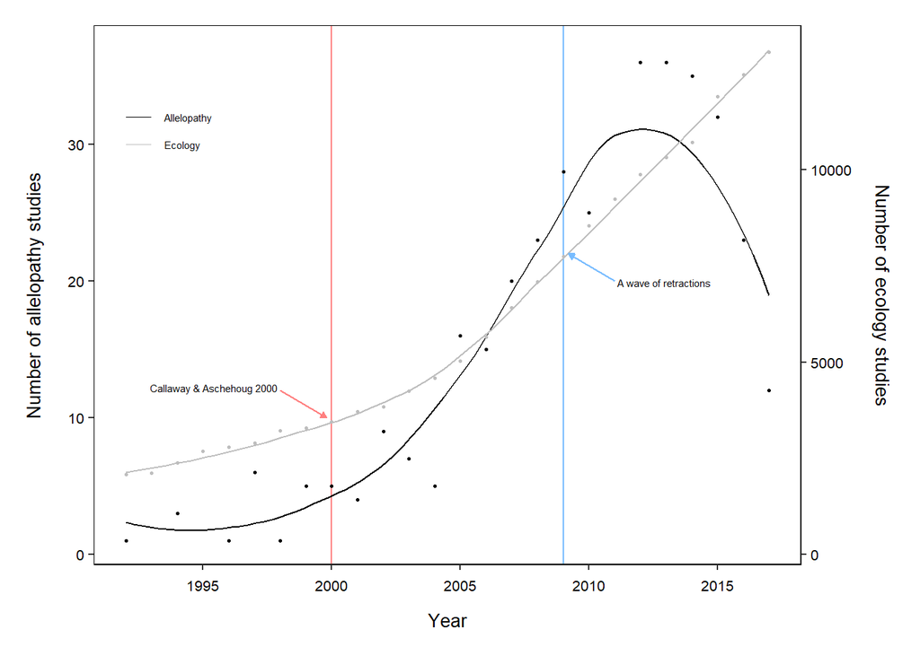

```r
paper_year %>% ggplot() +
  geom_vline(xintercept = 2009, color = desat('dodgerblue', 0.6), size = 0.5) +
  geom_vline(xintercept = 2000, color = desat('red', 0.5),        size = 0.5) +
  aes(x = year, y = n) +
  geom_smooth(se = F, colour = 'black', method = 'loess', size = 0.5) +
  geom_point(size = 0.6) +
  labs(y = 'Number of published papers\n', x = '\nYear') + theme +
  scale_x_continuous(limits = c(1992, 2017), breaks = 1990 + 1:5 *5, labels = 1990 + 1:5 *5) +
  #-----reference ---------#
  geom_point(aes(x = year, y = n_ecology), color = 'gray', size = 0.6) +
  geom_smooth(aes(x = year, y = n_ecology),se = F, colour = 'gray', method = 'loess', size = 0.5) +
  # ----- add text and arrows----#
  geom_segment(aes(x = 1998, y = 12, xend = 1999.8, yend = 10),
               arrow = arrow(length = unit(0.13, 'cm'), type='closed'),
               color = desat('red', 0.5), size = 0.4) +

  geom_segment(aes(x = 2011, y = 20, xend = 2009.2, yend = 22),
               arrow = arrow(length = unit(0.13, 'cm'), type='closed'),
               color = desat('dodgerblue', 0.6), size = 0.4) +

  annotate(geom="text", x= 1997.9, y= 12.2, label='Callaway & Aschehoug 2000', size = 2, hjust = 1) +
  annotate(geom="text", x= 2011.1, y= 19.9, label='A wave of retractions', size = 2, hjust = 0) +
  theme(axis.text.x = element_text(vjust = -1)) +
  # ------------legend -----------------#
  geom_segment(aes(x = 1992, y = 32, xend = 1993, yend = 32), size = 0.3) +
  annotate(geom="text", x = 1993.5, y = 32, label = 'Allelopathy', size = 2, hjust = 0) +
  geom_segment(aes(x = 1992, y = 30, xend = 1993, yend = 30), size = 0.3, color = 'gray') +
  annotate(geom="text", x = 1993.5, y = 30, label = 'Ecology',     size = 2, hjust = 0) +
  # second y axis
  scale_y_continuous(name = "Number of allelopathy studies\n",
                     sec.axis = sec_axis( trans=~./0.002813086, name="Number of ecology studies\n") )
```

```r
ggsave('./fig/number.pdf', height = 9/2.54, width = 14/2.54,
       useDingbats=FALSE)
```

boxplot (supplementary)

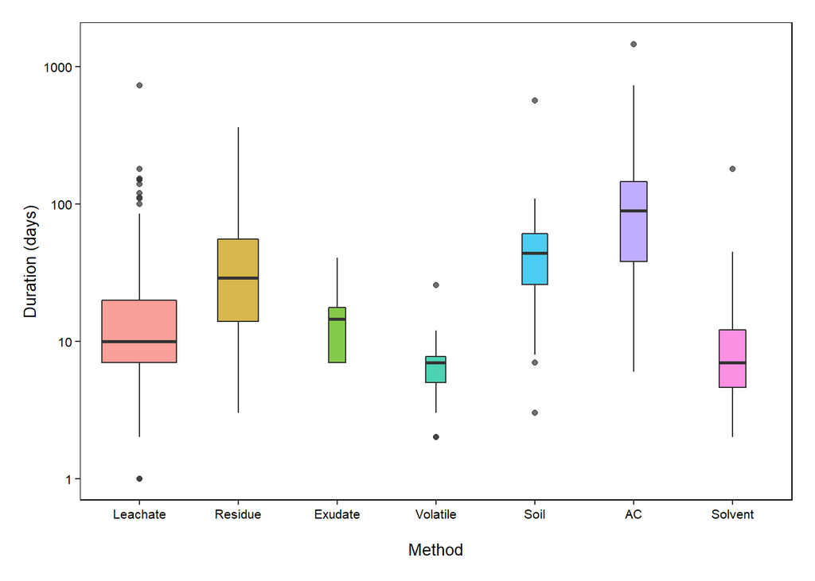

```r
t_method <- dat %>%
  group_by(Ref_ID, method) %>%
  summarise(mean_duration = mean(duration)) %>%
  mutate(method = str_to_title(method)) %>%
  mutate(method = ifelse(method == 'Ac', 'AC', as.character(method)))
t_method$method <- factor(t_method$method,
                         levels = c("Leachate", "Residue", "Exudate", 'Volatile', 'Soil', 'AC', 'Solvent'))
t_method %>% ggplot() +
  aes(x = method, y = mean_duration, fill = method) +
  geom_boxplot(varwidth = T, alpha = 0.7) + theme + scale_y_log10()+  theme(legend.position = "none") + labs(y = 'Duration (days)', x = '\nMethod')
```

```r
ggsave('./fig/method.pdf', height = 10/2.54, width = 14/2.54,
       useDingbats=FALSE)
```

tree

```r
pdf('./fig/phylo_tree.pdf', height = 15/2.54, width =  15/2.54)
plotTree(tree, type="fan",fsize=0.1,lwd=0.5, family = 2)
add.scale.bar(length = 50,cex = 0.7, font = 1, col = "black")
text(-276, -427,'Million years', cex = 0.7)
dev.off()
```

## 4.2 design

```r
vars <- get_variables(m_total)[grepl('b_',get_variables(m_total))] %>% str_remove('^b_')
# design
hypo_design <- hypothesis(m_total, c('Intercept = 0',
                                     paste(vars[1], ' + ', vars[grepl('method', vars)], '= 0'),
                                     paste(vars[1], ' + ', unique(dat$trait_scale) %>% sort, '* trait_scale  = 0'),
                                     'Intercept = 0', # controlled experiments
                                     paste(vars[1], ' + ', vars[grepl('exp_envi', vars)],    ' = 0')
))
```

```r
table_design <- obs_paper_num(dat, c('method', 'trait_dummy', 'exp_envi'),
                              hypo_design$hypothesis)
```

```r
# biological trait
vars_bio <- vars[grepl('life|crop', vars)]
hypo_list <- c()
for (i in 1:length(vars_bio)){
  hypo_i <- paste(vars[1], ' + ', unique(dat[,vars_bio[i]]) %>% sort, ' * ', vars_bio[i], ' = 0')
  hypo_list <- c(hypo_list, hypo_i)
}

hypo_trait <- hypothesis(m_total, hypo_list)

## origin
vars_origin <- vars[grepl('origin_', vars)]
# Here, I can the order, make it as:
#                             native      on native, native on naturalized, native on nonnaturalized
#                             naturalized on native, xxx
#                             casual      on native, xxx
vars_origin <- vars_origin[c(3, 4,
                             1, 5, 7,
                             2, 6, 8
                             )]
hypo_list <- c(paste(vars[1], ' = 0'))
for (i in 1:length(vars_origin)){
  hypo_i <- paste(vars[1], ' + ',  vars_origin[i], ' = 0')
  hypo_list <- c(hypo_list, hypo_i)
}



#
hypo_origin <- hypothesis(m_leach, hypo_list)
```

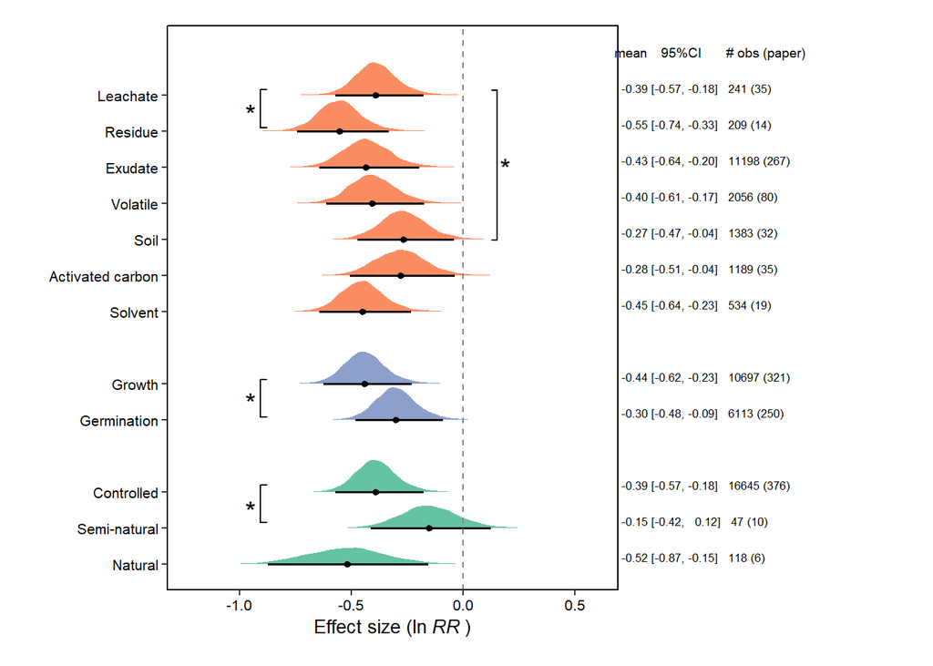

```r
cols <- c(c( '#00BA38', '#619CFF' ,'#F8766D'))
cols <- brewer.pal(3, 'Set2')[c(1, 3, 2)]
p0 <- (hypo_design$samples) %>%
  rownames_to_column('c') %>%
  pivot_longer(-c, names_to = "hypo", values_to = "value") %>%
  mutate(loc = str_remove(hypo, 'H'),
         loc = 13 - as.numeric(loc),
         #--------------colors---------------#
         group = ifelse(loc %in% 12:6, 'method',
                        ifelse(loc %in% 4:5, 'measurement','door')),
         #------ locations ----------------#
         loc = ifelse(loc %in% 12:6, loc + 2,
                      ifelse(loc %in% 4:6, loc + 1, loc))) %>%
  ggplot() + aes(x = value, y = loc,  fill = group) +
  scale_fill_manual(values = cols) +
  labs(x = expression('Effect size (ln'~italic('RR')~')'), y = '') +
  scale_y_continuous(breaks = c(1:3, 5:6, 8:14), labels = c( 'Natural', 'Semi-natural', 'Controlled',
                                                            'Germination', 'Growth',
                                                            'Solvent','Activated carbon','Soil', 'Volatile',
                                                            'Exudate',  'Residue', 'Leachate')) +
  #-----------plot---------#
  stat_halfeyeh(.width = 0.95, size = 1) +
  geom_vline(xintercept = 0, linetype = 'dashed', colour = rgb(0.5, 0.5, 0.5)) +
  theme + theme(legend.position = "none") +
  theme(plot.margin = margin(t = 0.5, r = 6, b = 0.5, l = 0.5, unit = "cm")) +
  geom_text(size = 2.3, data = table_design, hjust = 0,
            aes(x = 0.6, y = c(14:8, 6:5, 3:1) + 0.2, label = paste('      ', info_sum), fill = NA)) +

  coord_cartesian(clip = "off") +
  annotate(geom="text", x= 0.38, y= 15.2, label="                   mean    95%CI       # obs (paper)", hjust = 0, size = 2.5) +
  #------- add significance levels -------#
  bracketsGrob(0.22, 13.3/15, 0.22, 12.3/15, h= -0.01, lwd=1, col="black", type = 4, ticks = NA) %>% annotation_custom +
  bracketsGrob(0.72, 13.3/15, 0.72,  9.3/15, h=  0.01, lwd=1, col="black", type = 4, ticks = NA) %>% annotation_custom +
  bracketsGrob(0.22, 5.6/15,  0.22,  4.6/15, h= -0.01, lwd=1, col="black", type = 4, ticks = NA) %>% annotation_custom +
  bracketsGrob(0.22, 2.8/15,  0.22,  1.8/15, h= -0.01, lwd=1, col="black", type = 4, ticks = NA) %>% annotation_custom +
  annotate(geom="text", x= -.95, y= 13.5, label="*", size = 5) +
  annotate(geom="text", x= .19,  y= 12, label="*", size = 5) +
  annotate(geom="text", x= -.95, y= 5.5, label="*", size = 5) +
  annotate(geom="text", x= -.95, y= 2.5, label="*", size = 5)

p0
```

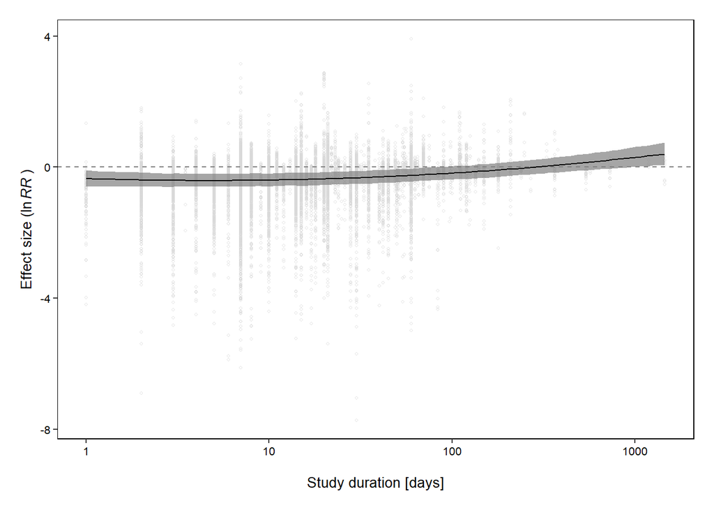

```r
# duration
median <- median(log(dat$duration))
p1 <- dat %>%
  data_grid(duration_scale = seq_range(duration_scale, 100),
            method = 'leachate', trait_scale = 0,
            lifespan_allelo_scale = 0, lifeform_allelo_scale = 0, crop_allelo_scale =0,
            lifespan_test_scale = 0, lifeform_test_scale = 0, crop_test_scale =0,
            exp_envi = 'Controlled',
            pd_scale = 0, allelo_origin_3level = 'native', test_origin_3level = 'native', se = median(se)
  ) %>%
  add_fitted_draws(m_total, re_formula = NA) %>%
  median_hdci(.width = 0.95) %>%
  ggplot(aes(x = duration_scale, y = .value)) +
  geom_point(data = dat, aes(x = duration_scale, y = eff_size), pch = 21, color = rgb(0.85,0.85,0.85, 0.7), size = 0.7) +
  geom_hline(yintercept = 0, linetype = 'dashed', colour = rgb(0.5, 0.5, 0.5)) +
  geom_ribbon(aes(ymin = .lower, ymax = .upper), fill = rgb(0.5, 0.5, 0.5, 0.7)) + geom_line() +
  labs(x = '\nStudy duration [days]', y = expression('Effect size (ln'~italic('RR')~')')) +
  theme + scale_x_continuous(breaks = log(10^(0:3)) - median , label = 10^(0:3))
p1
```

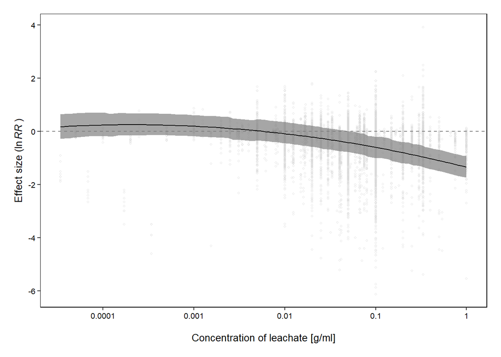

```r
# dose
median <- median(log(dat$dose) %>% na.omit())
p2 <- dat_leach %>%
  data_grid(duration_scale = 0, trait_scale = 0, door_scale = 0, plantpart = 'ab', color_scale = 0,
            lifespan_allelo_scale = 0, lifeform_allelo_scale = 0, crop_allelo_scale =0,
            lifespan_test_scale = 0, lifeform_test_scale = 0, crop_test_scale =0,
            pd_scale = 0,  allelo_origin_3level = 'native', test_origin_3level = 'native', se = median(se),
            dose_scale = seq_range(dose_scale,100)
  ) %>%
  add_fitted_draws(m_leach, re_formula = NA) %>%
  median_hdci(.width = 0.95) %>%
  ggplot(aes(x = dose_scale, y = .value)) +
  geom_point(data = dat_leach, aes(x = dose_scale, y = eff_size), pch = 21, color = rgb(0.85,0.85, 0.85, 0.7), size = 0.7) +
  geom_hline(yintercept = 0, linetype = 'dashed', colour = rgb(0.5, 0.5, 0.5)) +
  geom_ribbon(aes(ymin = .lower, ymax = .upper), fill = rgb(0.5, 0.5, 0.5, 0.7)) + geom_line() +
  labs(x = '\nConcentration of leachate [g/ml]', y = expression('Effect size (ln'~italic('RR')~')')) +
  theme + scale_x_continuous(breaks = log(10^c(-4, -3, -2, -1, 0)) - median ,
                             label = c('0.0001', '0.001', '0.01', '0.1', '1'))

p2
```

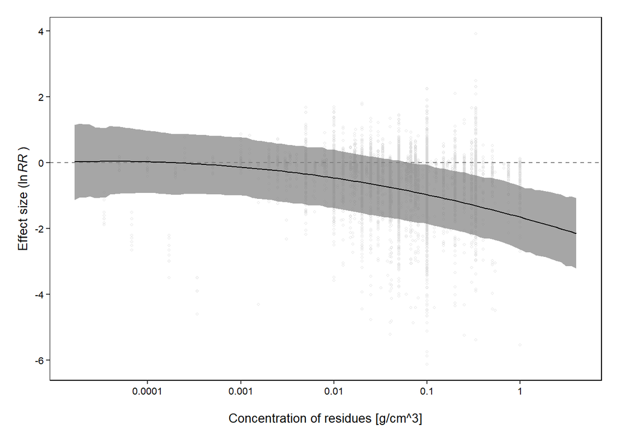

```r
p2_residue <- dat_residue %>%
  data_grid(duration_scale = 0, trait_scale = 0,  plantpart = 'ab', color_scale = 0,
            lifespan_allelo_scale = 0, lifeform_allelo_scale = 0, crop_allelo_scale =0,
            lifespan_test_scale = 0, lifeform_test_scale = 0, crop_test_scale =0,
             unit_type = 'w',
            pd_scale = 0,
            exp_envi = 'Controlled',
            test_origin = 'native', allelo_origin = 'native', se = median(se),
            dose_scale = seq_range(dose_scale,100)
  ) %>%
  add_fitted_draws(m_residue, re_formula = NA) %>%
  median_hdci(.width = 0.95) %>%
  ggplot(aes(x = dose_scale, y = .value)) +
  geom_point(data = dat_leach, aes(x = dose_scale, y = eff_size), pch = 21, color = rgb(0.85, 0.85, 0.85, 0.7), size = 0.7) +
  geom_hline(yintercept = 0, linetype = 'dashed', colour = rgb(0.5, 0.5, 0.5)) +
  geom_ribbon(aes(ymin = .lower, ymax = .upper), fill = rgb(0.5, 0.5, 0.5, 0.7)) + geom_line() +
  labs(x = '\nConcentration of residues [g/cm^3]', y = expression('Effect size (ln'~italic('RR')~')')) +
  theme + scale_x_continuous(breaks = log(10^c(-4, -3, -2, -1, 0)) - median ,
                             label = c('0.0001', '0.001', '0.01', '0.1', '1'))
p2_residue
```

```r
ggsave('./fig/design.pdf', height = 17/2.54, width = 17/2.54,
       grid.arrange(p0 + labs(tag = 'a'), p1 + labs(tag = 'b'), p2 + labs(tag = 'c'),
                    layout_matrix = matrix(c(1, 1, 2, 3), ncol = 2, byrow = T )),
       useDingbats=FALSE)

ggsave('./fig/residue.pdf', height = 14/2.54/2, width = 17/2.54/2,
       p2_residue,
       useDingbats=FALSE)
```

## 4.3 biological traits

```r
table_trait <- obs_paper_num(dat,list =
                               c('lifespan_allelo','lifeform_allelo','crop_allelo',
                                 'lifespan_test','lifeform_test','crop_test'),
                             hypo_trait$hypothesis)

new_loc <- data.frame(loc     = 1:12,
                      new_loc = c(1,2, 4,5, 7,8,
                                  11,12, 14, 15, 17, 18),
                      labels = rep(c('crop', 'wild', 'wood', 'herb', 'long-lived', 'short-lived'), 2)
)
```

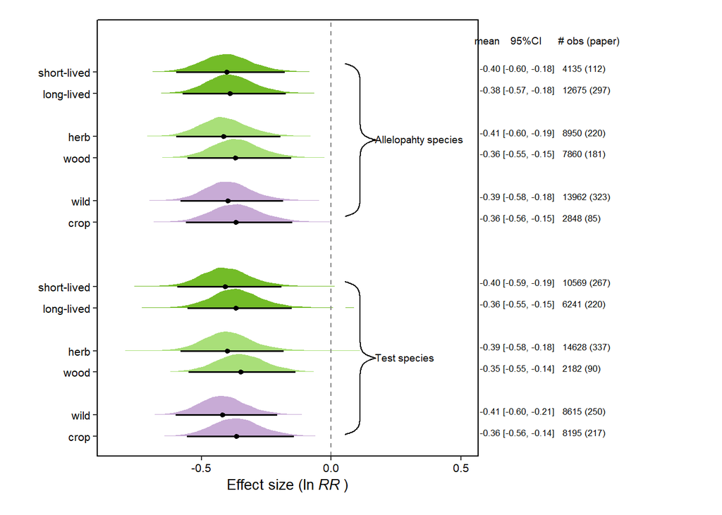

```r
cols = c(brewer.pal(12,'Paired')[c(9,3)], brewer.pal(12, 'PiYG')[9])
cols <- desat(cols, sat = 1.2)
p4 <- (hypo_trait$samples) %>%
  rownames_to_column('c') %>%
  pivot_longer(-c, names_to = "hypo", values_to = "value") %>%
  mutate(loc = str_remove(hypo, 'H'),
         loc = 13 - as.numeric(loc),
         #--------------groups---------------#
         group = ifelse(loc %in% c(11:12, 5:6), 'life_span',
                        ifelse(loc %in% c(9:10, 3:4), 'life_history','crop'))) %>%
  left_join(new_loc, by = 'loc') %>%
  ggplot() + aes(x = value, y = new_loc, fill = group) +
  scale_fill_manual(values = cols) +
  labs(x = expression('Effect size (ln'~italic('RR')~')'), y = '') +
  scale_y_continuous(breaks = c(1,2, 4,5, 7,8, 11, 12, 14, 15, 17, 18),
                     labels = rep(c('crop', 'wild', 'wood', 'herb', 'long-lived', 'short-lived'), 2)) +
  #---- plot----#
  stat_halfeyeh(.width = 0.95, size = 1) +
  geom_vline(xintercept = 0, linetype = 'dashed', colour = rgb(0.5, 0.5, 0.5)) +
  theme + theme(legend.position = "none") +
  theme(plot.margin = margin(t = 0.5, r = 6, b = 0.5, l = 0.5, unit = "cm")) +
  geom_text(size = 2.3, data = table_trait, hjust = 0,
            aes(x = 0.5, y = c(1,2, 4,5, 7,8, 11,12, 14, 15, 17, 18)[12:1] + 0.2,
                label = paste('      ',info_sum), fill = NA)) +
  coord_cartesian(clip = "off")

# add braces
p4 <- p4 + bracketsGrob(0.65, 0.05, 0.65, 0.4, h= -0.07, lwd=1, col="black") %>% annotation_custom +
  bracketsGrob(0.65, 0.55, 0.65, 0.9, h= -0.07, lwd=1, col="black") %>% annotation_custom +
  annotate(geom="text", x= 0.17, y=4.7,  label="Test species",        hjust = 0, size = 2.5) +
  annotate(geom="text", x= 0.17, y=14.9, label="Allelopahty species", hjust = 0, size = 2.5) +
  annotate(geom="text", x= 0.315, y=19.5, label="                       mean    95%CI      # obs (paper)", hjust = 0, size = 2.5)
p4
```

```r
ggsave('./fig/trait.pdf', p4, height = 10/2.54, width = 17/2.54)
```

## 4.4 evolutionary history

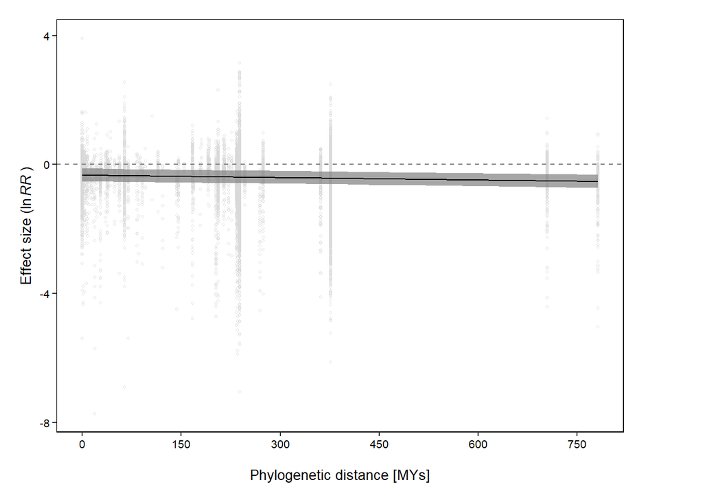

```r
### pd
median <- median(dat$pd)/max(dat$pd)

p_pd <- dat %>%
  data_grid(duration_scale = 0,
            method = 'leachate', trait_scale = 0,
            lifespan_allelo_scale = 0, lifeform_allelo_scale = 0, crop_allelo_scale =0,
            lifespan_test_scale = 0, lifeform_test_scale = 0, crop_test_scale =0,
            exp_envi = 'Controlled',
            allelo_origin_3level = 'native', test_origin_3level = 'native', se = median(se),
            pd_scale = seq_range(pd_scale, 100)
  ) %>%
  add_fitted_draws(m_total, re_formula = NA) %>%
  median_hdci(.width = 0.95) %>%
  ggplot(aes(x = pd_scale, y = .value)) +
  geom_point(data = dat, aes(x = pd_scale, y = eff_size), pch = 21, color = rgb(0.85,0.85,0.85, 0.7), size = 0.7) +
  geom_hline(yintercept = 0, linetype = 'dashed', colour = rgb(0.5, 0.5, 0.5)) +
  geom_ribbon(aes(ymin = .lower, ymax = .upper), fill = rgb(0.5, 0.5, 0.5, 0.7)) + geom_line() +
  labs(x = '\nPhylogenetic distance [MYs]', y = expression('Effect size (ln'~italic('RR')~')')) +
  theme + scale_x_continuous(breaks = 0:5*(1/max(dat$pd)*750/5) - median, label = seq(0, 750, 150)) +
  theme(plot.margin = margin(t = 0.5, r = 2, b = 0.5, l = 0.5, unit = "cm"))
p_pd
```

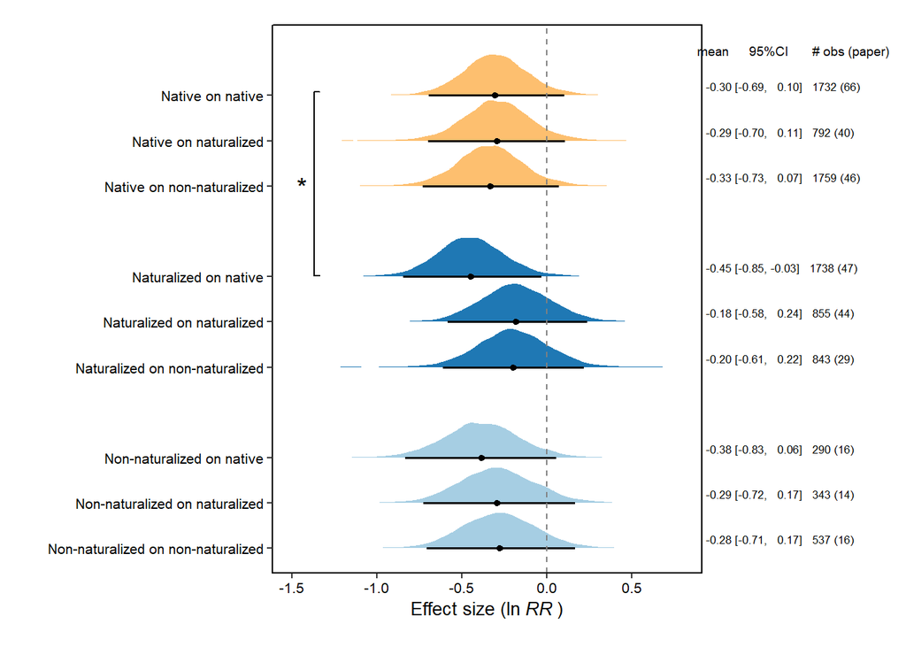

```r
#origin
cols <- brewer.pal(8,'Paired')[c(7,2,1)]
list <- outer(c('native on ', 'naturalized on ', 'non_naturalized on '),
              c('native',     'naturalized',     'non_naturalized' ), paste, sep = '') %>% t() %>% as.vector()

dat_leach$origin_comb_mult <- factor(dat_leach$origin_comb_mult, levels = list)
labels <- outer(c( 'Non-naturalized on ', 'Naturalized on ', 'Native on '),
              c( 'non-naturalized', 'naturalized','native'), paste, sep = '') %>% t() %>% as.vector()


table_origin <- obs_paper_num(dat_leach, list = 'origin_comb_mult', hypo_origin$hypothesis)

p_origin <- (hypo_origin$samples) %>%
  rownames_to_column('c') %>%
  pivot_longer(-c, names_to = "hypo", values_to = "value") %>%
  mutate(loc = str_remove(hypo, 'H'),
         #--------------groups---------------#
         group = ifelse(loc %in% c(1:3), 'native',
                        ifelse(loc %in% c(4:6), 'naturalized','non-naturalized')),
         loc = 10 - as.numeric(loc)) %>%
  mutate(loc = ifelse(loc %in% 1:3, loc,
                      ifelse(loc %in% 4:6, loc + 1, loc +2))) %>%
  ggplot() + aes(x = value, y = loc, fill = group) +
  scale_fill_manual(values = cols) +
  labs(x = expression('Effect size (ln'~italic('RR')~')'), y = '') +
  scale_y_continuous(breaks = c(1:3, 5:7, 9:11),
                     labels = labels) +
  scale_x_continuous(limits = c(-1.5,0.8)) +
  #---- plot----#
  stat_halfeyeh(.width = 0.95, size = 1) +
  geom_vline(xintercept = 0, linetype = 'dashed', colour = rgb(0.5, 0.5, 0.5)) +
  theme + theme(legend.position = "none") +
  theme(plot.margin = margin(t = 0.5, r = 4, b = 0.5, l = 0.5, unit = "cm")) +
  geom_text(size = 2.3, data = table_origin, hjust = 0,
            aes(x = 0.8, y = c(1:3, 5:7, 9:11)[9:1] + 0.2,
                label = paste('      ',info_sum), fill = NA)) +
  coord_cartesian(clip = "off") +
  annotate(geom="text", x= 0.45, y=12, label="                      mean      95%CI       # obs (paper)", hjust = 0, size = 2.5)+
  #-----------significance level ------#
  bracketsGrob(0.11, 12.3/14,  0.11, 7.6/14, h= -0.01, lwd=1, col="black", type = 4, ticks = NA) %>% annotation_custom +
  annotate(geom="text", x= -1.44, y= 9, label="*", size = 5)
p_origin
```

```r
ggsave('./fig/origin.pdf', height = 17/2.54, width = 17/2.54,
       grid.arrange(p_pd + labs(tag = 'a') + theme(plot.margin = margin(t = 0.5, r = 2, b = 0.5, l = 0.5, unit = "cm")),
                    p_origin + labs(tag = 'b'),
                    layout_matrix = matrix(c(NA, 1, 1, 1, NA,
                                             NA, 1, 1, 1, NA,
                                             2,  2, 2, 2, 2,
                                             2,  2, 2, 2, 2,
                                             2,  2, 2, 2, 2), nrow = 5, ncol = 5,byrow = T)),
       useDingbats=FALSE)
```

## 4.5 publication bias

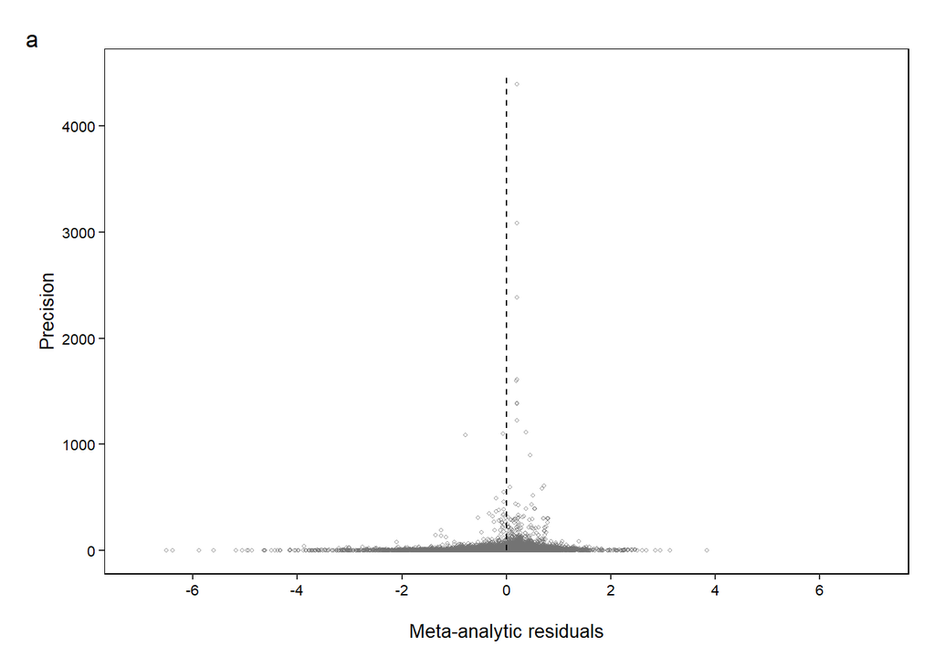

```r
col = '#FFC34D'
p_pub <- dat %>%
  ggplot(aes(x = meta_resid, y = 1/se)) +
  scale_x_continuous(limits = c(-7, 7), breaks = 2*(-3:3), labels = 2*(-3:3)) +
  labs(y = 'Precision', x = '\nMeta-analytic residuals', tag = 'a') +
  geom_point(pch = 21, colour = rgb(0.45, 0.45, 0.45, 0.7), size = 0.7) +
  geom_segment(aes(x = 0, y = 0, xend = 0, yend = 4500), colour = 'black', size = 0.5, linetype = 'dashed') + # x = 0
  theme
p_pub
```

all data

```r
p_pub_all <- dat %>%
  ggplot(aes(x = meta_resid, y = 1/se)) +
  scale_y_continuous(limits = c(0, 4500)) +
  scale_x_continuous(limits = c(-7, 7), breaks = 2*(-3:3), labels = 2*(-3:3)) +
  labs(y = 'Precision', x = '\nMeta-analytic residuals', tag = 'a') +
  geom_point(pch = 21, colour = rgb(0.45, 0.45, 0.45, 0.7), size = 0.7) +
  geom_segment(aes(x = 0, y = 0, xend = 0, yend = 4500), colour = 'black', size = 0.5, linetype = 'dashed') + # x = 0
  theme
```

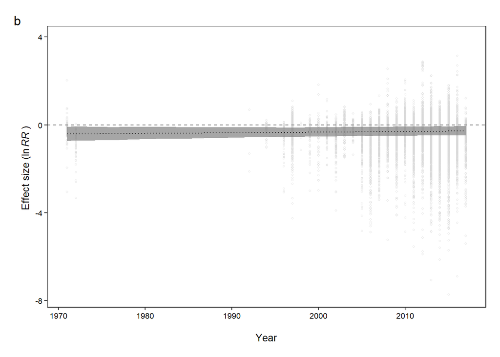

```r
p_year <- dat %>%
  #filter(year > 1980) %>%
  data_grid(year = seq_range(year, 100), se = median(se) ) %>%
  add_fitted_draws(m_year, re_formula = NA) %>%
  median_hdci(.width = 0.95) %>%
  ggplot(aes(x = year, y = .value)) +
  geom_point(data = dat, aes(x = year, y = eff_size), pch = 21, color = rgb(0.85,0.85,0.85, 0.7), size = 0.7) +
  geom_hline(yintercept = 0, linetype = 'dashed', colour = rgb(0.5, 0.5, 0.5)) +
  geom_ribbon(aes(ymin = .lower, ymax = .upper), fill = rgb(0.5, 0.5, 0.5, 0.7)) +
  geom_line(linetype = 'dotted') +
  labs(x = '\nYear', y = expression('Effect size (ln'~italic('RR')~')'~'\n'), tag = 'b') +
  theme
p_year
```

```r
ggsave('./fig/pub_bias.pdf', height = 15/2.54, width = 8.2/2.54,
       grid.arrange(p_pub, p_year, nrow = 2))

ggsave('./fig/pub_bias_sup.pdf', height = 17/2.54/2, width = 10/2.54,
      p_pub_all)
```

# 5 tables

```r
m_total_eco_use %>% Ftable(reorder = T, order = c(1:10, 17:18, 11:16, 19:24, 26, 25, 27)) %>%
  kable_styling(full_width = F) %>% save_kable('table/0_total_sup.png')

m_leach   %>% Ftable(reorder = T, order = c(1:2, 9:10, 12:16, 3:8, 11, 17:21,23,22,24)) %>%
  kable_styling(full_width = F) %>% save_kable('table/1_leach.png')
m_residue %>% Ftable(reorder = T, order = c(1:2,17, 9:10, 12:16, 18:19, 3:8, 11, 20:22)) %>%
  kable_styling(full_width = F) %>% save_kable('table/2_residue.png')
m_exudate %>% Ftable(reorder = T, order = c(1:2, 9:10,  3:8, 11:14)) %>%
  kable_styling(full_width = F) %>% save_kable('table/3_exudate.png')
m_VOC     %>% Ftable(reorder = T, order = c(1:2, 9:10,  3:8, 11:14)) %>%
  kable_styling(full_width = F) %>% save_kable('table/4_voc.png')
m_soil    %>% Ftable(reorder = T, order = c(1:2, 8:9,  3:7, 10:13)) %>%
  kable_styling(full_width = F) %>% save_kable('table/5_soil.png')
m_AC      %>% Ftable(reorder = T, order = c(1:2,12, 9:10,  3:8, 11,13:15)) %>%
  kable_styling(full_width = F) %>% save_kable('table/6_AC.png')
m_organic %>% Ftable(reorder = T, order = c(1:2, 6:7, 15:16,  9:14, 3:5, 8, 17:19)) %>%
  kable_styling(full_width = F) %>% save_kable('./table/7_organic.png')

I_square %>% kable_styling(full_width = F) %>% save_kable('table/hetero.png')
```